# Matimetika a Logika - Cviceni 2 (Matice)

Jan Schubert, Ivan Petrusek

Hlavnimi cili tohoto cviceni jsou:

1. Z hlediska R je cilem definovat novy objekt tridy matrix a ukazat/naznacit tri ruzne zpusoby vytvareni matic v R (rbind, cbind a matrix)
2. Dale z hlediska R predstavime subsetting objektu (zejmena matic) a ukazeme instalaci balicku “pracma” (z tohoto balicku budeme pouzivat funkce Rank a Trace)
3. Z hlediska matematiky je primarnim cilem demonstrovat zakladni operace s maticemi: transpozice matice, nasobeni matice skalarem, scitani matic a nasobeni matic
4. Vypocet tri dulezitych “charakteristik” matic: hodnost, determinant a stopa

Nejdrive si vytvorime 3 vektory o delce 4, ktere budou reprezentovat rok narozeni, vysku a jmeno ucastniku.

```r
rok_narozeni <- c(2000, 1999, 2000, 2001)
vyska <- c(167, 176, 189, 181)
jmeno <- c("Petr", "Jakub", "Pavel", "Jindra")
```

Matice je slozena z jednoho nebo vice radku a sloupcu. Radky se casto oznacuji pismenem $i$, sloupce pak pismenem $j$. Jednotlive elementy matice se oznacuji jako $a_{i,j}$. Hodnota v druhem radku a prvnim sloupci by tedy byla oznacena jako $a_{2,1}$

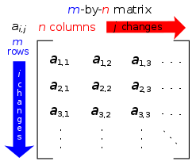

Zdroj: Wikipedia

Nyni z techto dvou numerickych vektoru vytvorime matici M. Jednim ze zpusobu, jak ji vytvorit je pomoci funkce matrix. Prvnim argumentem teto funkce jsou `data`. Zde specifikujete jednotlive hodnoty, ktere chceme do matice dosadit. Vsimnete si, ze zde pouzijeme funckci `c`, abychom spojili dva vektory. Jejich spojenim vznikne jeden vektor.

```r
print(c(rok_narozeni, vyska))
```

```
## [1] 2000 1999 2000 2001  167  176  189  181
```

Dalsim argumentem je pocet radku (`nrow`) a sloupcu (`ncol`). V nasem pripade mame 4 pozorovani (4 ucastniky kurzu) a 2 promenne (rok narozeni a vysku). Poslednim argumentem, ktery pouzivame je zda chceme vyplnit hodnoty radkem nebo sloupcem. `byrow` znamena, ze prvni hodnota nasich dat bude $M_{1,1}$, druha hodnota nasich dat bude vyplnena na pozici $M_{1,2}$ atd. Pokud zvolime `byrow=FALSE` bude prvni hodnota nasich dat vyplnena do $M_{1,1}$, druha hodnota nasich dat do $M_{2,1}$ atd. V nasem pripade chceme, aby prvni sloupec znacil vek narozeni a uvedeme tedy `byrow=FALSE`.

```r
matice_student <- matrix(data = c(rok_narozeni, vyska),
                         nrow = 4,
                         ncol = 2,
                         byrow = FALSE)
print(matice_student)
```

```
##      [,1] [,2]
## [1,] 2000  167
## [2,] 1999  176
## [3,] 2000  189
## [4,] 2001  181
```

Tridu objektu muzeme potvrdit pomoci funkce `class`.

```r
class(matice_student)
```

```
## [1] "matrix"
```

Pocet radku a sloupcu matice muzeme zobrazit pomoci funkce `dim`. Nase matice ma 4 radky a 2 sloupce. Vystupem funkce `dim` je vektor, ktery muzeme ulozit do noveho objektu a pouzit ho dale, pokud bude potreba.

```r
dimenze_matice <- dim(matice_student)
print(dimenze_matice)
```

```
## [1] 4 2
```

Dalsim zpusobem jak vytvorit matici je pomoci funkci `cbind` nebo `rbind`. Obe funkce spoji vektory jako sloupce nebo jako radky.

```r
cbind(rok_narozeni, vyska)
```

```
##      rok_narozeni vyska
## [1,]         2000   167
## [2,]         1999   176
## [3,]         2000   189
## [4,]         2001   181
```

```r
rbind(rok_narozeni, vyska)
```

```
##              [,1] [,2] [,3] [,4]
## rok_narozeni 2000 1999 2000 2001
## vyska         167  176  189  181
```

Matice v R se vyznacuje tim, ze vsechny prvky musi byt stejneho typu (character, numeric, logical). Pokud se budeme snazit vytvorit matici, ktera se sklada z ruznych typu vektoru, hodnoty se automaticky ponizi na nizsi tridu. V priklade dole se snazime kombinovat ciselne a textove hodnoty. R vytvori matici, kde budou numericke hodnoty ponizeny na textove.

```r
matrix(c(1,2,"Tomas"), ncol = 1, nrow = 3)
```

```
##      [,1]
## [1,] "1"
## [2,] "2"
## [3,] "Tomas"
```

Radky a slopuce matice muzeme pojmenovat, abychom meli lepsi prehled o tom, co jednotlive radky/sloupce vyjadruji. V nasem pripade vyjadruji jednotlive radky jmena ucastniku a sloupce rok narozeni a vysku.

```r
rownames(matice_student) <- jmeno
colnames(matice_student) <- c("rok_narozeni", "vyska")
print(matice_student)
```

```
##        rok_narozeni vyska
## Petr           2000   167
## Jakub          1999   176
## Pavel          2000   189
## Jindra         2001   181
```

Nyni se zamerime na nektere matematicke operace s maticemi. Vytvorime si k tomu tri nove matice X, Y a Z.

```r
X <- matrix(c(2, 0, 1, 0, 2, 3),
            byrow = TRUE,
            nrow = 2,
            ncol = 3)
Y <- matrix(c(1, -2, 0, 1, 2, 3),
            byrow = TRUE,
            nrow = 2,
            ncol = 3)
Z <- matrix(c(1, 2, 0, -1, 1, 1),
            byrow = TRUE,
            nrow = 3,
            ncol = 2)
```

Nejdrive si ukazeme jak udelat transpozici matice. Nasledujici animace znazornuje jak muzeme transpozici provest manualne.

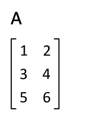

Zdroj: Wikipedia

V programu R provedeme transpozici pomoci funkce `t`.

```r
t(X)
```

```
##      [,1] [,2]
## [1,]    2    0
## [2,]    0    2
## [3,]    1    3
```

Dale si ukazeme, jak vynasobit matici skalarem. Muzete to udelat tak, ze matici vynasobime pozadovanym cislem. Vysledkem je matice o stejnem poctu radku a sloupcu. Kazdy prvek matice se jednoduse vynasobi. Muzeme tuto operaci take zapsat jako $k * M = k * m_{ij}$, kde $k$ je skalar a $M$ nase matice.

```r
X * 3
```

```
##      [,1] [,2] [,3]
## [1,]    6    0    3
## [2,]    0    6    9
```

Secteni matice A s matici B $A + B = C$ udelame tak, ze secteme prvky na stejnych radcich a sloupcich $a_{ij} + b_{ij} = c_{ij}$. Scitovat tedy muzeme pouze dve matice se stejnymi dimenzemi.

```r
X + Y
```

```
##      [,1] [,2] [,3]
## [1,]    3   -2    1
## [2,]    1    4    6
```

Nasobeni matice A s matici B provedeme tak, ze nejprve provedeme skalarni souci prvniho radku matice A a prvniho sloupce matice B. Dale vezmeme prvni radek matice A a druhy sloupec matice B a vypocitame skalarni soucin. Takto postupujeme dale, dokud neprojdeme vsechny radky a sloupce.

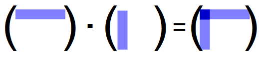

Zdroj: matematika.cz

V programu R provedeme nasobeni matic pomoci prikazu `%*%`, coz je stejny prikaz, ktery pouzijeme pro skalarni soucin dvou vektoru.

```r
X %*% Z
```

```
##      [,1] [,2]
## [1,]    3    5
## [2,]    3    1
```

Pokud si predstavite nasobeni matice s matici je zrejme, ze ne vsechny matice lze mezi sebou vynasobit. Pokud matice nelze vynasobit, vrati nam R chybu, ze nelze operaci provest.

```r
tryCatch({X %*% Y}, error = function(e) nasobeni_error <<- e)
print(nasobeni_error)
```

```
## <simpleError in X %*% Y: non-conformable arguments>
```

Jednotlive prvky matice `M` muzeme v R zobrazit pomoci `M[i,j]`, kde `i` vyjadruje radek matice a `j` jeji sloupec. Stejne tak muzeme zobrazit jednotlive prvky vektoru `V`. Protoze vektor nema zadne sloupce, muzete tak udelat pomoci `V[i]`. Dole je nekolik prikladu zobrazeni jednotlivych prvku nebo celych radku/sloupcu.

```r
#vektory
rok_narozeni[1]
```

```
## [1] 2000
```

```r
# dva prvky vektoru, soucasne prvni a ctvrty prvek
rok_narozeni[c(1, 4)]
```

```
## [1] 2000 2001
```

```r
#jeden prvek matice
matice_student[1, 1]
```

```
## [1] 2000
```

```r
#druhy sloupec matice
matice_student[, 2]
```

```
##   Petr  Jakub  Pavel Jindra
##    167    176    189    181
```

```r
# prvni a treti radek matice
matice_student[c(1, 3), ]
```

```
##       rok_narozeni vyska
## Petr          2000   167
## Pavel         2000   189
```

Nakonec si ukazeme, jak vypocitat hodnost, determinant a stopu matice. Abychom tyto operace mohli provest, musime si nainstalovat externi balicek. Balicky jsou zakladni soucasti ekosystemu R a jsou ulozeny na serveru CRAN. Zakladni instalace programu R obsahuje nekolik klicovych balicku, ktere jsme pouzivali doposud (jako `base`, `graphics` apod.). Tyto balicky jsou stazeny a nainstalovany automaticky pri zakladni instalaci R. Dalsi balicky je potreba instalovat pomoci prikazu `install.packages()`. Pokud uz balicek mate nainstalovany a chcete ho pouzivat, musite to R rici pomoci funkce `library()` (ta nacte tento balicek do vasi session). Dole si ukazeme jak nainstalovat balicek `pracma` a jak ho nacist do nasi soucasne session.

```r
install.packages("pracma")
library(pracma)
```

Nyni se muzeme pustit do jednotlivych vypoctu. Hodnost matice udava pocet nezavislych sloupcu nebo radku v matici a muzete ji vypocitat pomoci funckce `Rank` z balicku `pracma`. Nadefinujeme si matici A. Pomoci funkce `Rank` zjistime, ze tato matice ma hodnost 2. Existuji tedy 2 nezavisle radky nebou sloupce teto matice.

```r
# Pouzijeme matice A a C z Prikladu 2 cviceni
# matici A vytvarime tak, ze uvnitr funkce matrix vytvorime vektor se vsemi prvky matice
A <- matrix(c(2, 1, 2, 1, 1, 3), byrow = FALSE, nrow = 3)
print(A)
```

```
##      [,1] [,2]
## [1,]    2    1
## [2,]    1    1
## [3,]    2    3
```

```r
Rank(A) # Hodnost matice A
```

```
## [1] 2
```

Determinant matice vypocitate pomoci funkce `det`. Stopa matice je soucet prvku na hlavni diagonale a muzeme ji vypocitat pomoci funkce `Trace` z balicku `pracma` nebo manualne pomoci souctu (`sum`) diagonalnich prvku (`diag`). Zde je priklad obou vypoctu.

```r
C <- matrix(c(2, 1, 0, 1, 2, 1, 1, 3, 2), byrow = FALSE, nrow = 3)
print(C)
```

```
##      [,1] [,2] [,3]
## [1,]    2    1    1
## [2,]    1    2    3
## [3,]    0    1    2
```

```r
det(C)
```

```
## [1] 1
```

```r
Trace(C)
```

```
## [1] 6
```

```r
sum(diag(C))
```

```
## [1] 6
```

Determinant a stopu je mozne spocitat pouze pro ctvercove matice. V pripade, ze matice neni ctvercova nam vrati R chybu dane operace.

```r
tryCatch({det(A)}, error = function(e) det_error <<- e)
# ukazka ERROR: determinant lze pocitat pouze pro ctvercovou matici
print(det_error)
```

```
## <simpleError in determinant.matrix(x, logarithm = TRUE, ...): 'x' must be a square matrix>
```

```r
tryCatch({Trace(A)}, error = function(e) trace_error <<- e)
# ukazka ERROR: stopu lze pocitat pouze pro ctvercovou matici
print(trace_error)
```

```
## <simpleError in Trace(A): Matrix 'a' must be square.>
```

Bonus: Jako bonus, ktery neni povinny, ale je uzitecny, zminime funkce `colMeans` a `rowMeans`. Tyto funkce slouzi k vypoctu prumeru hodnot sloupce nebo radku. Stejne tak muzeme vypocitat sumu hodnot sloupce/radku pomoci funkci `colSums`/`rowSums`. Tyto operace jsou uzitecne, kdyz chceme vypocitat nejake souhrnne statistiky nasich dat. Pokud by nas napriklad zajimal prumerny vek a vyska ucastniku kurzu, muzete je vypocitat pomoci nasledujiciho kodu.

```r
# nejdrive vypocitame vek misto roku narozeni. Vyslednou hodnotu nahradime hodnotu v prvnim sloupci matice "matice_student"
matice_student[, 1] <- 2020 - matice_student[, 1]
# a zmenime jmeno tohoto sloupce
colnames(matice_student)[1] <- "vek"

#vypocitat prumer vsech sloupcu v matici
colMeans(matice_student)
```

```
##    vek  vyska
##  20.00 178.25
```